# Clusterwise Regression with German Credit Data

Mark Preston

August 12, 2018

## Customer Creditability using German Credit Data and Clusterwise Regression

I’ll be using the German Credit data to predict the amount a customer loan will be. Having done this in previous assignments, this analysis will use clusterwise regression as the prediction method. To use this method, I’ve loaded the appropriate clusterwise regression function.

```r
library(tidyverse)
library(caret)
library(Metrics)
library(knitr)
library(kableExtra)

#ggplot plotting theme preference
theme_set(
  theme_minimal()
)

#custom table function used throughout analysis
custom_kable <- function(x){
  kable(x, format = "html") %>%
    kable_styling(bootstrap_options = "striped")
}

german_credit <- read.csv("German.Credit.csv")
```

### Generate a training (70%) and hold out (30%) set using same seed at Logistic assignment

As per the assignment, I’m dropping categorical variables while developing the training and holdout samples. This leaves six numeric features to predict credit amount with.

```r
german_credit <- german_credit %>%
  rename(Duration = Duration.of.Credit..month.,
         Age = Age..years.,
         Amount = Credit.Amount,
         Rate = Instalment.per.cent,
         Residence_Yrs = Duration.in.Current.address)

german_credit <- german_credit %>%
  select(Duration, Age, Amount, Rate,
         Residence_Yrs, No.of.Credits.at.this.Bank, No.of.dependents)

set.seed(1017)
data_split <- createDataPartition(y = german_credit$Amount, p = .7, list = F)

training <- german_credit %>%
  slice(data_split) %>%
  select(Amount, everything())

holdout <- german_credit %>%
  slice(-data_split) %>%
  select(Amount, everything())
```

### Build clusterwise regression models with 1, 2, and 3 clusters

I’ve developed a clusterwise model for one, two, and three clusters. With these, I’ll be able to compare each model and select the most appropriate solution.

```r
cwr_one <- clustreg(dat = training, k = 1, tries = 1, sed = 1017, niter = 1)

cwr_two <- clustreg(dat = training, k = 2, tries = 2, sed = 1017, niter = 10)

cwr_three <- clustreg(dat = training, k = 3, tries = 2, sed = 1017, niter = 10)
```

### Explore the models using R2, interpretability, and holdout performance

Starting here, I’ve plotted the best R2 form each of the three models. There is a large increase from one to two clusters (.50 to .82) but, the jump from two to three is less major (.82 to .89). Using this metric, it looks like the three cluster solution is preferable. That said, I think two might be a reasonable option depending on holdout performance and interpretability. However, I don’t think one cluster is a good choice here.

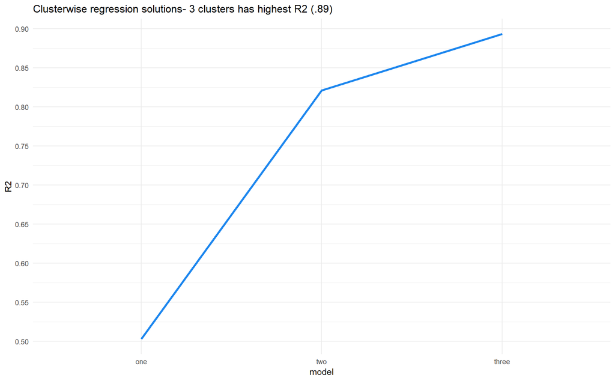

```r
rsquare_compare <- data.frame(
  set = "training",
  model = factor(c("one", "two", "three"),
                 levels = c("one", "two", "three")),
  R2 = c(cwr_one$rsq.best, cwr_two$rsq.best, cwr_three$rsq.best)
)

rsquare_compare %>%
  ggplot(aes(model, R2, group = set)) +
  geom_line(size = 1.4, colour = "dodgerblue2") +
  scale_y_continuous(breaks = seq(0, 1, .05)) +
  labs(title = "Clusterwise regression solutions- 3 clusters has highest R2 (.89)")
```

With this in mind, I’ll focus on the regression summaries for both the two and three cluster models. The two summary shows several significant terms, including duration, rate, number of existing credits, and number of dependents. The interpretations all seem intuitive as well, for example the amount decreasing with rate increases and increasing as duration increases.

```r
cwr_two$results
```

```
## [[1]]
##
## Call:
## lm(formula = dat[c.best == i, ])
##
## Residuals:
##     Min      1Q  Median      3Q     Max
## -3146.3  -948.8  -415.1   522.9 10005.5
##
## Coefficients:
##                            Estimate Std. Error t value Pr(>|t|)
## (Intercept)                 4695.26     998.80   4.701 6.03e-06 ***
## Duration                     218.14      12.47  17.498  < 2e-16 ***
## Age                           24.76      15.93   1.554  0.12239
## Rate                        -957.97     140.40  -6.823 2.34e-10 ***
## Residence_Yrs                251.05     148.22   1.694  0.09249 .
## No.of.Credits.at.this.Bank  -638.30     241.50  -2.643  0.00913 **
## No.of.dependents            -929.88     377.64  -2.462  0.01499 *
## ---
## Signif. codes:  0 '***' 0.001 '**' 0.01 '*' 0.05 '.' 0.1 ' ' 1
##
## Residual standard error: 1887 on 143 degrees of freedom
## Multiple R-squared:  0.7504, Adjusted R-squared:   0.74
## F-statistic: 71.66 on 6 and 143 DF,  p-value: < 2.2e-16
##
##
## [[2]]
##
## Call:
## lm(formula = dat[c.best == i, ])
##
## Residuals:
##     Min      1Q  Median      3Q     Max
## -3194.8  -583.5   -19.1   526.6  3285.6
##
## Coefficients:
##                            Estimate Std. Error t value Pr(>|t|)
## (Intercept)                1852.809    223.529   8.289 9.01e-16 ***
## Duration                    113.944      3.385  33.658  < 2e-16 ***
## Age                          10.419      3.560   2.927  0.00357 **
## Rate                       -598.376     35.589 -16.814  < 2e-16 ***
## Residence_Yrs                21.071     36.334   0.580  0.56221
## No.of.Credits.at.this.Bank  -45.630     73.441  -0.621  0.53465
## No.of.dependents           -316.774    116.681  -2.715  0.00684 **
## ---
## Signif. codes:  0 '***' 0.001 '**' 0.01 '*' 0.05 '.' 0.1 ' ' 1
##
## Residual standard error: 914.7 on 543 degrees of freedom
## Multiple R-squared:  0.7085, Adjusted R-squared:  0.7052
## F-statistic: 219.9 on 6 and 543 DF,  p-value: < 2.2e-16
```

Interestingly, the significant coefficients change for the three cluster model with number of credits having a much higher p-value. However, the summary still seems interpretable and intuitive, which is a good sign.

```r
cwr_three$results
```

```
## [[1]]
##
## Call:
## lm(formula = dat[c.best == i, ])
##
## Residuals:
##     Min      1Q  Median      3Q     Max
## -1608.8  -471.7  -127.5   326.6  3888.9
##
## Coefficients:
##                            Estimate Std. Error t value Pr(>|t|)
## (Intercept)                  85.962    314.264   0.274   0.7847
## Duration                    163.351      4.174  39.133  < 2e-16 ***
## Age                          21.090      4.332   4.868 1.97e-06 ***
## Rate                       -792.100     44.243 -17.904  < 2e-16 ***
## Residence_Yrs                83.090     45.316   1.834   0.0679 .
## No.of.Credits.at.this.Bank -114.491     89.842  -1.274   0.2037
## No.of.dependents           1666.818    156.937  10.621  < 2e-16 ***
## ---
## Signif. codes:  0 '***' 0.001 '**' 0.01 '*' 0.05 '.' 0.1 ' ' 1
##
## Residual standard error: 788.4 on 257 degrees of freedom
## Multiple R-squared:  0.8982, Adjusted R-squared:  0.8958
## F-statistic: 377.7 on 6 and 257 DF,  p-value: < 2.2e-16
##
##
## [[2]]
##
## Call:
## lm(formula = dat[c.best == i, ])
##
## Residuals:
##     Min      1Q  Median      3Q     Max
## -2129.6  -982.8  -461.3   365.2  8391.3
##
## Coefficients:
##                            Estimate Std. Error t value Pr(>|t|)
## (Intercept)                11202.80    1221.80   9.169 3.32e-14 ***
## Duration                     210.17      15.60  13.470  < 2e-16 ***
## Age                           10.14      20.77   0.488   0.6268
```

[output cut: 21 more lines]

```
## Coefficients:
##                            Estimate Std. Error t value Pr(>|t|)
## (Intercept)                 889.240    174.468   5.097 5.74e-07 ***
## Duration                     88.792      2.829  31.391  < 2e-16 ***
## Age                           5.612      2.974   1.887   0.0600 .
## Rate                       -436.785     29.539 -14.787  < 2e-16 ***
## Residence_Yrs                 5.814     29.560   0.197   0.8442
## No.of.Credits.at.this.Bank   65.753     59.506   1.105   0.2700
## No.of.dependents            201.192     85.737   2.347   0.0195 *
## ---
## Signif. codes:  0 '***' 0.001 '**' 0.01 '*' 0.05 '.' 0.1 ' ' 1
##
## Residual standard error: 592.3 on 340 degrees of freedom
## Multiple R-squared:  0.7594, Adjusted R-squared:  0.7551
## F-statistic: 178.8 on 6 and 340 DF,  p-value: < 2.2e-16
```

Moving onto holdout performance, I’ve developed predictions for amount on the holdout set. These can be used to see how the models do on unseen data while also highlighting stability as well.

```r
cwrone_pred <- clustreg.predict(results = cwr_one, newdat = holdout)

cwrtwo_pred <- clustreg.predict(results = cwr_two, newdat = holdout)

cwrthree_pred <- clustreg.predict(results = cwr_three, newdat = holdout)
```

The plot below highlights that the R2 drop from training to holdout is minimal for all three solutions. Again, this points to a three cluster solution being the most appropriate approach here.

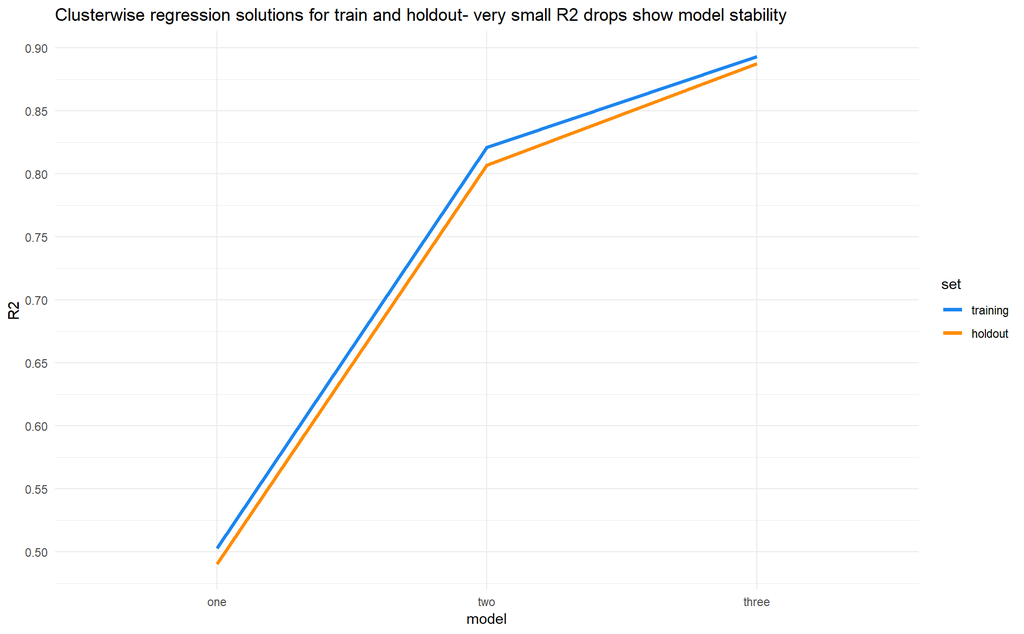

```r
rsquare_compare <- data.frame(
  set = "holdout",
  model = factor(c("one", "two", "three"),
                 levels = c("one", "two", "three")),
  R2 = c(cwrone_pred$rsq[1], cwrtwo_pred$rsq[1], cwrthree_pred$rsq[1])) %>%
  bind_rows(rsquare_compare)

rsquare_compare %>%
  mutate(set = factor(set, levels = c("training", "holdout"))) %>%
  ggplot(aes(model, R2, group = set, colour = set)) +
  geom_line(size = 1.4) +
  scale_y_continuous(breaks = seq(0, 1, .05)) +
  scale_colour_manual(values = c("dodgerblue2", "darkorange")) +
  labs(title = "Clusterwise regression solutions for train and holdout- very small R2 drops show model stability")
```

Cluster size can be used to assess stability as well. For the two model, the cluster proportions from train to test are almost identical, which shows stability.

```r
c(train = prop.table(table(cwr_two$cluster)),
  test = prop.table(table(cwrtwo_pred$cluster))) %>%
  custom_kable()
```

| train.1 | 0.2142857 |
| --- | --- |
| train.2 | 0.7857143 |
| test.1 | 0.2266667 |
| test.2 | 0.7733333 |

Building on this, the same finding is evident for the three cluster group. At this point, I’m strongly considering three as the preferred solution.

```r
c(train = prop.table(table(cwr_three$cluster)), test = prop.table(table(cwrthree_pred$cluster))) %>%
  custom_kable()
```

| train.1 | 0.3771429 |
| --- | --- |
| train.2 | 0.1271429 |
| train.3 | 0.4957143 |
| test.1 | 0.4166667 |
| test.2 | 0.1200000 |
| test.3 | 0.4633333 |

However, I still need to assess predictive performance. For this, I’ll compare the holdout amount to the predicted values. I’ve decided against using one cluster so this review will only assess the two and three solutions.

```r
holdout <- holdout %>%
  mutate(two_pred = cwrtwo_pred$yhat,
         three_pred = cwrthree_pred$yhat)

holdout %>%
  select(Amount, two_pred, three_pred) %>%
  head() %>%
  custom_kable()
```

| Amount | two_pred | three_pred |
| --- | --- | --- |
| 1049 | 1450.9770 | 1148.408 |
| 841 | 1984.9025 | 1500.452 |
| 3398 | 2248.5763 | 3193.367 |
| 1361 | 1161.5876 | 1264.302 |
| 1098 | 1863.7841 | 1461.098 |
| 1424 | 798.3368 | 1227.707 |

To formalize this, I’ll use mean average percentage error (mape). As seen in the table below, the three cluster outperforms two with an average percentage miss of about 21%.

```r
c(two_mape = mape(actual = holdout$Amount, predicted = holdout$two_pred),
  three_mape = mape(actual = holdout$Amount, predicted = holdout$three_pred)) %>%
  custom_kable()
```

| two_mape | 0.3359131 |
| --- | --- |
| three_mape | 0.2148540 |

Given the review, I think the three cluster model is the best solution here. As a final visual, I’ve plotted the actuals and the predicted values for the solution. The clusterwise model shows some differences from the actuals but, the fit isn’t too bad. The results would need to be reviewed with business stakeholders to ascertain if the predictions were valuable for the bank.

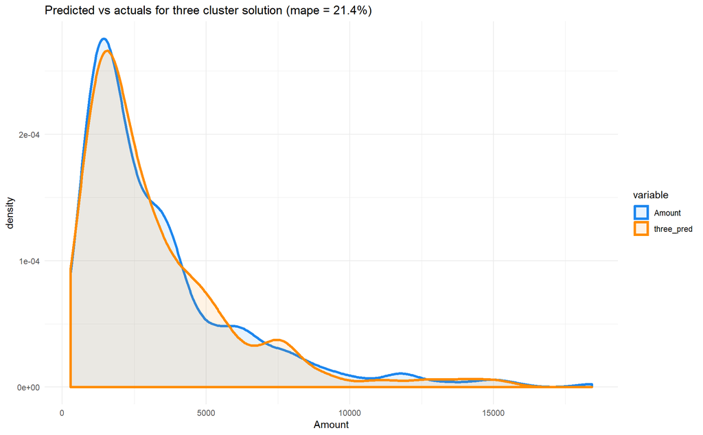

```r
holdout %>%
  select(Amount, three_pred) %>%
  gather(key = "variable", value = "values") %>%
  ggplot(aes(values, colour = variable, fill = variable)) +
  geom_density(size = 1.3, alpha = .1) +
  scale_colour_manual(values = c("dodgerblue2", "darkorange")) +
  scale_fill_manual(values = c("dodgerblue2", "darkorange")) +
  labs(title = "Predicted vs actuals for three cluster solution (mape = 21.4%)",
       x = "Amount")
```

As a final review, I wanted to look at the averages for each variable by cluster to better understand their composition. The clusters seem homogeneous across most variables with the exception of amount. Given this, it appears that the clusters form a high, medium, and low amount clustering solution.

```r
holdout %>%
  select(-two_pred, -three_pred) %>%
  mutate(cluster = cwrthree_pred$cluster) %>%
  group_by(cluster) %>%
  summarise(avg_amount = mean(Amount),
            avg_duration = mean(Duration),
            avg_age = mean(Age),
            avg_rate = mean(Rate),
            avg_residence = mean(Residence_Yrs),
            avg_credits = mean(No.of.Credits.at.this.Bank),
            avg_credits = mean(No.of.dependents)) %>%
  custom_kable()
```

| cluster | avg_amount | avg_duration | avg_age | avg_rate | avg_residence | avg_credits |
| --- | --- | --- | --- | --- | --- | --- |
| 1 | 3687.144 | 20.32000 | 34.15200 | 3.168000 | 2.864000 | 1.112000 |
| 2 | 7747.639 | 25.80556 | 36.05556 | 2.666667 | 2.833333 | 1.222222 |
| 3 | 1924.259 | 20.21583 | 35.97842 | 2.964029 | 2.877698 | 1.136691 |